# Initial Analysis Report

# Descriptive Analysis

### Student’s Performance By Teachers

The following table summarizes student’s performance using six different statistics, aggregated by each teachers. The NULL values are removed to get the statistics.

```r
data = STAR %>%
        group_by(star1, experience1, tethnicity1, schoolid1) %>%
        summarise(
          median = median(math1, na.rm = T),
          mean = mean(math1, na.rm = T),
          min = min(math1, na.rm = T),
          max = max(math1, na.rm = T),
          Q1 = quantile(math1, 0.25, na.rm = T),
          Q3 = quantile(math1, 0.75, na.rm = T)
        )
head(data, 10) %>%
  kbl(caption = "Summary Measures of each Teachers") %>%
  kable_classic(full_width = F, html_font = "Cambria")
```

Summary Measures of each Teachers

| star1 | experience1 | tethnicity1 | schoolid1 | median | mean | min | max | Q1 | Q3 |
| --- | --- | --- | --- | --- | --- | --- | --- | --- | --- |
| regular | 0 | cauc | 5 | 512 | 517.5000 | 456 | 592 | 503.75 | 532.75 |
| regular | 0 | cauc | 32 | 481 | 485.4583 | 446 | 542 | 462.50 | 503.75 |
| regular | 0 | cauc | 58 | 549 | 544.5385 | 479 | 592 | 529.00 | 565.75 |
| regular | 0 | cauc | 66 | 538 | 532.3913 | 472 | 592 | 491.50 | 564.50 |
| regular | 0 | cauc | 70 | 535 | 537.6087 | 461 | 584 | 516.50 | 562.00 |
| regular | 0 | cauc | 77 | 545 | 550.2857 | 488 | 601 | 538.00 | 567.00 |
| regular | 0 | afam | 23 | 555 | 557.1250 | 515 | 627 | 532.00 | 579.50 |
| regular | 0 | afam | 45 | 567 | 566.1667 | 446 | 653 | 557.00 | 584.00 |
| regular | 1 | cauc | 22 | 487 | 488.3500 | 425 | 542 | 476.75 | 506.25 |
| regular | 1 | cauc | 37 | 526 | 519.6500 | 458 | 612 | 506.50 | 529.00 |

The following histogram shows a distribution of mean score by each teacher. For our dataset, mean is better summary statistics than median since math score will not have any outliers due to its fixed maximum. Note that distribution looks approximately normal by the central limit theorem.

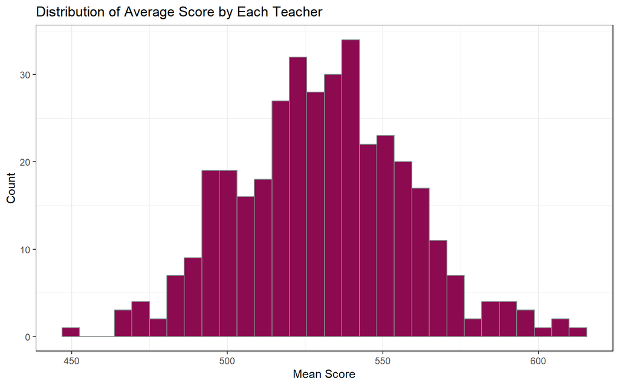

```r
#Distribution of Average Score by Each Teacher
ggplot(data, aes(x = mean)) +
  geom_histogram(fill = "deeppink4", color = "azure4") +
  labs(x = "Mean Score",
       y = "Count",
       title = "Distribution of Average Score by Each Teacher") +
  theme_bw() +
  theme(panel.grid.major.y = element_blank(),
        legend.position = "off")
```

### Possibly Relevant Variables

According to the description of the data, it is clear that teacher is also an important source of variation. The observation lead to the conclusion that experiences, ladder and earned-degree of the teacher should be counted as part of our analysis. The `experience1` is only numerical variable. `ladder1` and `degree1` are categorical variables.

Also, there is some possibility that student’s level of economic status can be an significant source of the variation. Therefore, `lunch1` should be also regarded as a possibly relevant variable. This is also a categorical variable.

It is important to note that, according to the frequency table, the data contains many NA values. According to the description of the dataset, NA values indicates student who was not able to take the test. For our analysis, these observations will be removed for the sake of analysis.

```r
data2 = STAR %>%
          select(lunch1, degree1, ladder1, experience1)

lunch1_df <- as.data.frame(table(data2$lunch1, useNA = "always"))
colnames(lunch1_df) <- c("lunch1", "Frequency")

degree1_df <- as.data.frame(table(data2$degree1, useNA = "always"))
colnames(degree1_df) <- c("degree1", "Frequency")

ladder1_df <- as.data.frame(table(data2$ladder1, useNA = "always"))
colnames(ladder1_df) <- c("ladder1", "Frequency")

experience1_df <- as.data.frame(
  summarise(data2,
          median = median(experience1, na.rm = T),
          mean = mean(experience1, na.rm = T),
          min = min(experience1, na.rm = T),
          max = max(experience1, na.rm = T),
          Q1 = quantile(experience1, 0.25, na.rm = T),
          Q3 = quantile(experience1, 0.75, na.rm = T)
        ))

kable(experience1_df, booktabs =TRUE,
      caption = "Summary Statistics for experience1")
```

Summary Statistics for experience1

| median | mean | min | max | Q1 | Q3 |
| --- | --- | --- | --- | --- | --- |
| 10 | 11.63348 | 0 | 42 | 4 | 17 |

```r
kable(list(lunch1_df, degree1_df, ladder1_df), booktabs =TRUE,
      caption = "Frequency Table for lunch1, degree1 and ladder1")
```

Frequency Table for lunch1, degree1 and ladder1

| lunch1 | Frequency |
| --- | --- |
| non-free | 3221 |
| free | 3430 |
| NA | 4947 |

| degree1 | Frequency |
| --- | --- |
| bachelor | 4456 |
| master | 2294 |
| specialist | 38 |
| phd | 22 |
| NA | 4788 |

| ladder1 | Frequency |
| --- | --- |
| level1 | 4492 |
| level2 | 114 |
| level3 | 291 |
| apprentice | 718 |
| probation | 666 |
| notladder | 506 |
| NA | 4811 |

The following bar plots for `lunch1`, `degree1` and `ladder1` shows that we have many NA values. Except `lunch1`, `degree1` and `ladder1` shows a uneven distribution, indicating that it is possible that many teachers who participated to the research are not very experienced teacher.

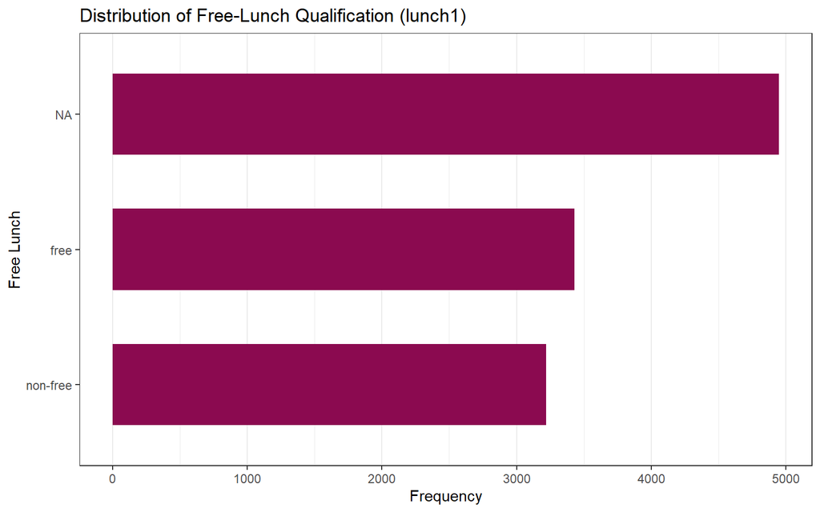

```r
ggplot(lunch1_df,
       aes(x = Frequency, y = lunch1)) +
  geom_bar(stat = "identity", fill = "deeppink4", width = 0.6) +
  labs(x = "Frequency",
       y = "Free Lunch",
       title = "Distribution of Free-Lunch Qualification (lunch1)") +
  theme_bw() +
  theme(panel.grid.major.y = element_blank(),
        legend.position = "off")
```

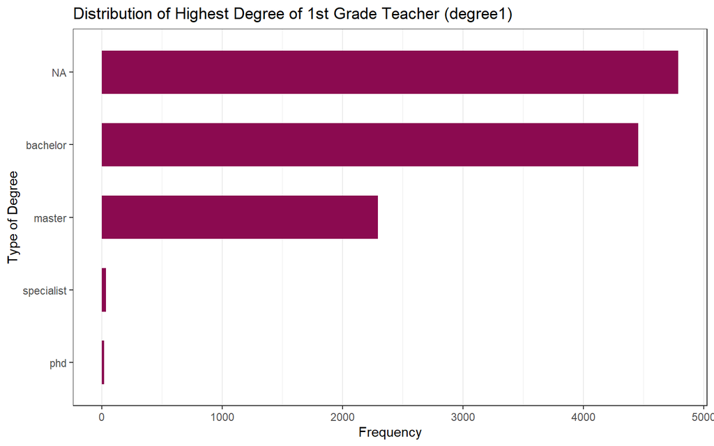

```r
ggplot(degree1_df,
       aes(x = Frequency, y = reorder(degree1, Frequency))) +
  geom_bar(stat = "identity", fill = "deeppink4", width = 0.6) +
  labs(x = "Frequency",
       y = "Type of Degree",
       title = "Distribution of Highest Degree of 1st Grade Teacher (degree1)") +
  theme_bw() +
  theme(panel.grid.major.y = element_blank(),
        legend.position = "off")
```

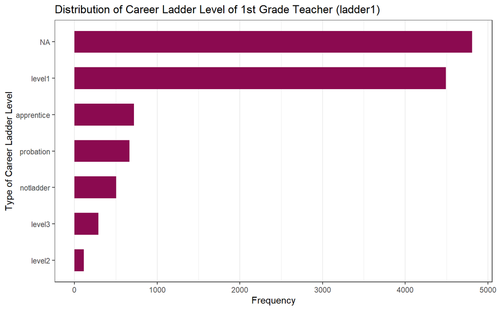

```r
ggplot(ladder1_df,
       aes(x = Frequency, y = reorder(ladder1, Frequency))) +
  geom_bar(stat = "identity", fill = "deeppink4", width = 0.6) +
  labs(x = "Frequency",
       y = "Type of Career Ladder Level",
       title = "Distribution of Career Ladder Level of 1st Grade Teacher (ladder1)") +
  theme_bw() +
  theme(panel.grid.major.y = element_blank(),
        legend.position = "off")
```

The boxplot of `experience1` shows a right-skewed distribution, which supports our claim that there is a possibility that many teachers who participated the research are not very experienced.

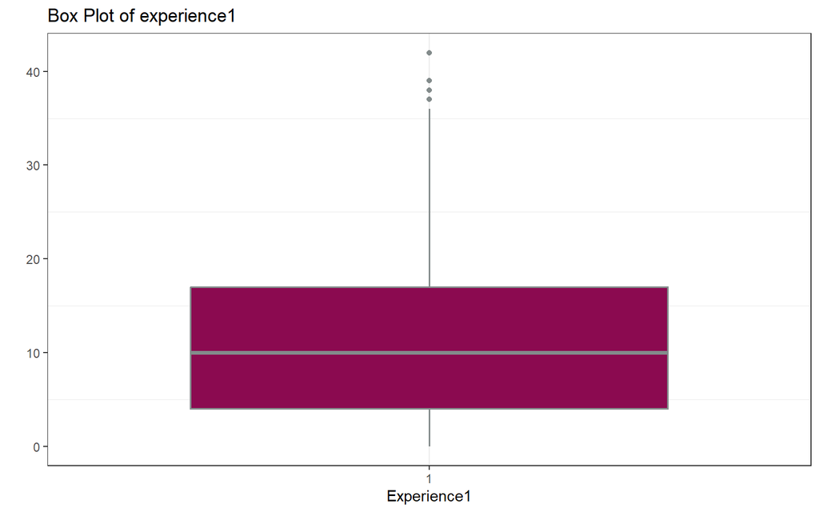

```r
ggplot(data2, aes(x = factor(1), y = experience1)) +
  geom_boxplot(fill = "deeppink4", color = "azure4", lwd =0.7) +
  labs(title="Box Plot of experience1", x="Experience1", y = " ") +
  theme_bw() +
  theme(panel.grid.major.y = element_blank(),
        legend.position = "off")
```